# ANCOVA in Vocabulario Ensinado (Vocabulario Ensinado)

Geiser C. Challco geiser@alumni.usp.br

- Descriptive Statistics of Initial Data
- ANCOVA and Pairwise for one factor: **grupo**
  - Without remove non-normal data
  - Computing ANCOVA and PairWise After removing non-normal data (OK)
    - Plots for ancova
    - Checking linearity assumption
    - Checking normality and homogeneity
- ANCOVA and Pairwise for two factors **grupo:Sexo**
  - Without remove non-normal data
  - Computing ANCOVA and PairWise After removing non-normal data (OK)
    - Plots for ancova
    - Checking linearity assumption
    - Checking normality and homogeneity
- ANCOVA and Pairwise for two factors **grupo:Zona**
  - Without remove non-normal data
  - Computing ANCOVA and PairWise After removing non-normal data (OK)
    - Plots for ancova
    - Checking linearity assumption
    - Checking normality and homogeneity
- ANCOVA and Pairwise for two factors **grupo:Cor.Raca**
  - Without remove non-normal data
  - Computing ANCOVA and PairWise After removing non-normal data (OK)
    - Plots for ancova
    - Checking linearity assumption
    - Checking normality and homogeneity
- ANCOVA and Pairwise for two factors **grupo:vocab.teach.quintile**
  - Without remove non-normal data
  - Computing ANCOVA and PairWise After removing non-normal data (OK)
    - Plots for ancova
    - Checking linearity assumption
    - Checking normality and homogeneity
- Summary of Results
  - Descriptive Statistics
  - ANCOVA Table Comparison
  - PairWise Table Comparison
  - EMMS Table Comparison

**NOTE**:

- Teste ANCOVA para determinar se houve diferenças significativas no Vocabulario Ensinado (medido usando pre- e pos-testes).
- ANCOVA test to determine whether there were significant differences in Vocabulario Ensinado (measured using pre- and post-tests).

# Descriptive Statistics of Initial Data

```r
df <- get.descriptives(dat, c(dv.pre, dv.pos), c("grupo"),
                       include.global = T, symmetry.test = T, normality.test = F)
df <- plyr::rbind.fill(
  df, do.call(plyr::rbind.fill, lapply(lfatores2, FUN = function(f) {
    if (nrow(dat) > 0 && sum(!is.na(unique(dat[[f]]))) > 1)
      get.descriptives(dat, c(dv.pre,dv.pos), c("grupo", f),
                       symmetry.test = T, normality.test = F)
    }))
)
(df <- df[,c(fatores1[fatores1 %in% colnames(df)],"variable",
             colnames(df)[!colnames(df) %in% c(fatores1,"variable")])])
```

```
##           grupo Sexo   Zona Cor.Raca vocab.teach.quintile        variable   n  mean median min max    sd    se
## 1      Controle <NA>   <NA>     <NA>                 <NA> vocab.teach.pre 100 4.560    4.5   0  10 2.298 0.230
## 2  Experimental <NA>   <NA>     <NA>                 <NA> vocab.teach.pre 181 4.796    5.0   1   9 1.954 0.145
## 3          <NA> <NA>   <NA>     <NA>                 <NA> vocab.teach.pre 281 4.712    5.0   0  10 2.082 0.124
## 4      Controle <NA>   <NA>     <NA>                 <NA> vocab.teach.pos 100 5.070    5.0   0  10 2.508 0.251
## 5  Experimental <NA>   <NA>     <NA>                 <NA> vocab.teach.pos 181 5.210    5.0   1  11 2.188 0.163
## 6          <NA> <NA>   <NA>     <NA>                 <NA> vocab.teach.pos 281 5.160    5.0   0  11 2.304 0.137
## 7      Controle    F   <NA>     <NA>                 <NA> vocab.teach.pre  53 4.679    5.0   0  10 2.335 0.321
## 8      Controle    M   <NA>     <NA>                 <NA> vocab.teach.pre  47 4.426    4.0   0   9 2.272 0.331
## 9  Experimental    F   <NA>     <NA>                 <NA> vocab.teach.pre  96 4.958    5.0   1   9 2.031 0.207
## 10 Experimental    M   <NA>     <NA>                 <NA> vocab.teach.pre  85 4.612    4.0   1   9 1.859 0.202
## 11     Controle    F   <NA>     <NA>                 <NA> vocab.teach.pos  53 5.094    5.0   0  10 2.640 0.363
## 12     Controle    M   <NA>     <NA>                 <NA> vocab.teach.pos  47 5.043    5.0   0   9 2.377 0.347
## 13 Experimental    F   <NA>     <NA>                 <NA> vocab.teach.pos  96 5.698    5.5   1  11 2.206 0.225
## 14 Experimental    M   <NA>     <NA>                 <NA> vocab.teach.pos  85 4.659    4.0   1   9 2.044 0.222
```

[output cut: 98 more lines]

| grupo | Sexo | Zona | Cor.Raca | vocab.teach.quintile | variable | n | mean | median | min | max | sd | se | ci | iqr | symmetry | skewness | kurtosis |
| --- | --- | --- | --- | --- | --- | --- | --- | --- | --- | --- | --- | --- | --- | --- | --- | --- | --- |
| Controle |  |  |  |  | vocab.teach.pre | 100 | 4.560 | 4.5 | 0 | 10 | 2.298 | 0.230 | 0.456 | 3.00 | YES | 0.050 | -0.769 |
| Experimental |  |  |  |  | vocab.teach.pre | 181 | 4.796 | 5.0 | 1 | 9 | 1.954 | 0.145 | 0.287 | 3.00 | YES | 0.175 | -0.643 |
|  |  |  |  |  | vocab.teach.pre | 281 | 4.712 | 5.0 | 0 | 10 | 2.082 | 0.124 | 0.244 | 3.00 | YES | 0.091 | -0.616 |
| Controle |  |  |  |  | vocab.teach.pos | 100 | 5.070 | 5.0 | 0 | 10 | 2.508 | 0.251 | 0.498 | 4.00 | YES | -0.166 | -0.786 |
| Experimental |  |  |  |  | vocab.teach.pos | 181 | 5.210 | 5.0 | 1 | 11 | 2.188 | 0.163 | 0.321 | 3.00 | YES | 0.356 | -0.343 |
|  |  |  |  |  | vocab.teach.pos | 281 | 5.160 | 5.0 | 0 | 11 | 2.304 | 0.137 | 0.271 | 3.00 | YES | 0.109 | -0.465 |
| Controle | F |  |  |  | vocab.teach.pre | 53 | 4.679 | 5.0 | 0 | 10 | 2.335 | 0.321 | 0.644 | 4.00 | YES | 0.008 | -0.928 |
| Controle | M |  |  |  | vocab.teach.pre | 47 | 4.426 | 4.0 | 0 | 9 | 2.272 | 0.331 | 0.667 | 3.00 | YES | 0.089 | -0.664 |
| Experimental | F |  |  |  | vocab.teach.pre | 96 | 4.958 | 5.0 | 1 | 9 | 2.031 | 0.207 | 0.411 | 2.50 | YES | 0.056 | -0.774 |
| Experimental | M |  |  |  | vocab.teach.pre | 85 | 4.612 | 4.0 | 1 | 9 | 1.859 | 0.202 | 0.401 | 3.00 | YES | 0.293 | -0.481 |
| Controle | F |  |  |  | vocab.teach.pos | 53 | 5.094 | 5.0 | 0 | 10 | 2.640 | 0.363 | 0.728 | 5.00 | YES | -0.106 | -0.862 |
| Controle | M |  |  |  | vocab.teach.pos | 47 | 5.043 | 5.0 | 0 | 9 | 2.377 | 0.347 | 0.698 | 4.00 | YES | -0.259 | -0.843 |
| Experimental | F |  |  |  | vocab.teach.pos | 96 | 5.698 | 5.5 | 1 | 11 | 2.206 | 0.225 | 0.447 | 3.00 | YES | 0.369 | -0.379 |
| Experimental | M |  |  |  | vocab.teach.pos | 85 | 4.659 | 4.0 | 1 | 9 | 2.044 | 0.222 | 0.441 | 3.00 | YES | 0.278 | -0.669 |
| Controle |  | Rural |  |  | vocab.teach.pre | 38 | 4.658 | 4.5 | 1 | 9 | 1.963 | 0.318 | 0.645 | 3.00 | YES | 0.135 | -0.951 |
| Controle |  | Urbana |  |  | vocab.teach.pre | 18 | 4.222 | 4.0 | 0 | 10 | 2.510 | 0.592 | 1.248 | 3.50 | YES | 0.416 | -0.471 |
| Controle |  |  |  |  | vocab.teach.pre | 44 | 4.614 | 5.0 | 0 | 9 | 2.508 | 0.378 | 0.762 | 4.25 | YES | -0.105 | -1.087 |
| Experimental |  | Rural |  |  | vocab.teach.pre | 56 | 4.786 | 5.0 | 1 | 9 | 2.006 | 0.268 | 0.537 | 3.00 | YES | 0.064 | -0.823 |
| Experimental |  | Urbana |  |  | vocab.teach.pre | 33 | 4.636 | 4.0 | 1 | 8 | 1.578 | 0.275 | 0.559 | 2.00 | YES | 0.081 | -0.419 |
| Experimental |  |  |  |  | vocab.teach.pre | 92 | 4.859 | 5.0 | 1 | 9 | 2.057 | 0.214 | 0.426 | 3.00 | YES | 0.210 | -0.777 |
| Controle |  | Rural |  |  | vocab.teach.pos | 38 | 4.842 | 5.0 | 0 | 8 | 2.552 | 0.414 | 0.839 | 4.00 | YES | -0.341 | -1.141 |
| Controle |  | Urbana |  |  | vocab.teach.pos | 18 | 5.444 | 5.0 | 2 | 10 | 2.382 | 0.561 | 1.184 | 3.50 | YES | 0.287 | -1.127 |
| Controle |  |  |  |  | vocab.teach.pos | 44 | 5.114 | 5.0 | 0 | 10 | 2.554 | 0.385 | 0.776 | 3.00 | YES | -0.132 | -0.741 |
| Experimental |  | Rural |  |  | vocab.teach.pos | 56 | 5.143 | 5.0 | 1 | 11 | 2.244 | 0.300 | 0.601 | 2.25 | NO | 0.517 | -0.279 |
| Experimental |  | Urbana |  |  | vocab.teach.pos | 33 | 5.727 | 6.0 | 2 | 11 | 2.125 | 0.370 | 0.754 | 3.00 | NO | 0.631 | 0.173 |
| Experimental |  |  |  |  | vocab.teach.pos | 92 | 5.065 | 5.0 | 1 | 10 | 2.173 | 0.227 | 0.450 | 3.25 | YES | 0.172 | -0.803 |
| Controle |  |  | Branca |  | vocab.teach.pre | 3 | 6.000 | 7.0 | 2 | 9 | 3.606 | 2.082 | 8.957 | 3.50 | few data | 0.000 | 0.000 |
| Controle |  |  | Indígena |  | vocab.teach.pre | 1 | 7.000 | 7.0 | 7 | 7 |  |  |  | 0.00 | few data | 0.000 | 0.000 |
| Controle |  |  | Parda |  | vocab.teach.pre | 38 | 4.789 | 5.0 | 1 | 9 | 1.833 | 0.297 | 0.602 | 2.00 | YES | -0.133 | -0.635 |
| Controle |  |  |  |  | vocab.teach.pre | 58 | 4.293 | 4.0 | 0 | 10 | 2.492 | 0.327 | 0.655 | 3.75 | YES | 0.212 | -0.881 |
| Experimental |  |  | Amarela |  | vocab.teach.pre | 1 | 3.000 | 3.0 | 3 | 3 |  |  |  | 0.00 | few data | 0.000 | 0.000 |
| Experimental |  |  | Branca |  | vocab.teach.pre | 19 | 5.053 | 5.0 | 1 | 8 | 1.747 | 0.401 | 0.842 | 2.00 | YES | -0.431 | -0.474 |
| Experimental |  |  | Parda |  | vocab.teach.pre | 53 | 4.642 | 4.0 | 1 | 9 | 2.030 | 0.279 | 0.559 | 3.00 | YES | 0.293 | -0.757 |
| Experimental |  |  |  |  | vocab.teach.pre | 108 | 4.843 | 5.0 | 1 | 9 | 1.963 | 0.189 | 0.374 | 3.00 | YES | 0.189 | -0.639 |
| Controle |  |  | Branca |  | vocab.teach.pos | 3 | 5.000 | 5.0 | 2 | 8 | 3.000 | 1.732 | 7.452 | 3.00 | few data | 0.000 | 0.000 |
| Controle |  |  | Indígena |  | vocab.teach.pos | 1 | 8.000 | 8.0 | 8 | 8 |  |  |  | 0.00 | few data | 0.000 | 0.000 |
| Controle |  |  | Parda |  | vocab.teach.pos | 38 | 4.974 | 5.0 | 0 | 9 | 2.584 | 0.419 | 0.849 | 4.00 | YES | -0.301 | -1.109 |
| Controle |  |  |  |  | vocab.teach.pos | 58 | 5.086 | 5.0 | 0 | 10 | 2.473 | 0.325 | 0.650 | 3.75 | YES | -0.036 | -0.590 |
| Experimental |  |  | Amarela |  | vocab.teach.pos | 1 | 6.000 | 6.0 | 6 | 6 |  |  |  | 0.00 | few data | 0.000 | 0.000 |
| Experimental |  |  | Branca |  | vocab.teach.pos | 19 | 5.211 | 6.0 | 2 | 8 | 2.175 | 0.499 | 1.048 | 4.00 | YES | 0.021 | -1.759 |
| Experimental |  |  | Parda |  | vocab.teach.pos | 53 | 5.264 | 5.0 | 1 | 11 | 2.371 | 0.326 | 0.654 | 2.00 | YES | 0.421 | -0.462 |
| Experimental |  |  |  |  | vocab.teach.pos | 108 | 5.176 | 5.0 | 1 | 11 | 2.126 | 0.205 | 0.406 | 3.00 | YES | 0.361 | -0.177 |
| Controle |  |  |  | 1st quintile | vocab.teach.pre | 22 | 1.455 | 2.0 | 0 | 2 | 0.739 | 0.157 | 0.327 | 1.00 | few data | 0.000 | 0.000 |
| Controle |  |  |  | 2nd quintile | vocab.teach.pre | 12 | 3.000 | 3.0 | 3 | 3 | 0.000 | 0.000 | 0.000 | 0.00 | few data | 0.000 | 0.000 |
| Controle |  |  |  | 3rd quintile | vocab.teach.pre | 30 | 4.467 | 4.0 | 4 | 5 | 0.507 | 0.093 | 0.189 | 1.00 | few data | 0.000 | 0.000 |
| Controle |  |  |  | 4th quintile | vocab.teach.pre | 12 | 6.000 | 6.0 | 6 | 6 | 0.000 | 0.000 | 0.000 | 0.00 | few data | 0.000 | 0.000 |
| Controle |  |  |  | 5th quintile | vocab.teach.pre | 24 | 7.583 | 7.0 | 7 | 10 | 0.881 | 0.180 | 0.372 | 1.00 | NO | 1.222 | 0.332 |
| Experimental |  |  |  | 1st quintile | vocab.teach.pre | 22 | 1.727 | 2.0 | 1 | 2 | 0.456 | 0.097 | 0.202 | 0.75 | few data | 0.000 | 0.000 |
| Experimental |  |  |  | 2nd quintile | vocab.teach.pre | 28 | 3.000 | 3.0 | 3 | 3 | 0.000 | 0.000 | 0.000 | 0.00 | few data | 0.000 | 0.000 |
| Experimental |  |  |  | 3rd quintile | vocab.teach.pre | 64 | 4.438 | 4.0 | 4 | 5 | 0.500 | 0.062 | 0.125 | 1.00 | few data | 0.000 | 0.000 |
| Experimental |  |  |  | 4th quintile | vocab.teach.pre | 30 | 6.000 | 6.0 | 6 | 6 | 0.000 | 0.000 | 0.000 | 0.00 | few data | 0.000 | 0.000 |
| Experimental |  |  |  | 5th quintile | vocab.teach.pre | 37 | 7.622 | 7.0 | 7 | 9 | 0.794 | 0.131 | 0.265 | 1.00 | few data | 0.000 | 0.000 |
| Controle |  |  |  | 1st quintile | vocab.teach.pos | 22 | 3.045 | 3.0 | 0 | 10 | 2.535 | 0.540 | 1.124 | 3.00 | NO | 0.788 | 0.286 |
| Controle |  |  |  | 2nd quintile | vocab.teach.pos | 12 | 4.833 | 4.5 | 3 | 8 | 1.749 | 0.505 | 1.112 | 1.50 | NO | 0.699 | -0.880 |
| Controle |  |  |  | 3rd quintile | vocab.teach.pos | 30 | 4.733 | 5.0 | 1 | 8 | 1.856 | 0.339 | 0.693 | 2.75 | YES | -0.060 | -0.912 |
| Controle |  |  |  | 4th quintile | vocab.teach.pos | 12 | 6.000 | 6.5 | 0 | 8 | 2.523 | 0.728 | 1.603 | 2.50 | NO | -1.090 | 0.033 |
| Controle |  |  |  | 5th quintile | vocab.teach.pos | 24 | 7.000 | 8.0 | 2 | 10 | 1.978 | 0.404 | 0.835 | 2.25 | NO | -0.743 | -0.306 |
| Experimental |  |  |  | 1st quintile | vocab.teach.pos | 22 | 3.409 | 4.0 | 1 | 7 | 1.436 | 0.306 | 0.637 | 1.00 | YES | 0.128 | 0.090 |
| Experimental |  |  |  | 2nd quintile | vocab.teach.pos | 28 | 4.500 | 4.0 | 2 | 8 | 1.503 | 0.284 | 0.583 | 1.25 | NO | 0.536 | -0.028 |
| Experimental |  |  |  | 3rd quintile | vocab.teach.pos | 64 | 4.891 | 5.0 | 1 | 9 | 1.912 | 0.239 | 0.478 | 3.00 | YES | 0.060 | -0.812 |
| Experimental |  |  |  | 4th quintile | vocab.teach.pos | 30 | 5.567 | 6.0 | 1 | 11 | 2.315 | 0.423 | 0.864 | 3.00 | YES | 0.240 | -0.427 |
| Experimental |  |  |  | 5th quintile | vocab.teach.pos | 37 | 7.081 | 7.0 | 3 | 11 | 2.019 | 0.332 | 0.673 | 3.00 | YES | -0.029 | -0.814 |

# ANCOVA and Pairwise for one factor: **grupo**

## Without remove non-normal data

```r
pdat = remove_group_data(dat[!is.na(dat[["grupo"]]),], "vocab.teach.pos", "grupo")

pdat.long <- rbind(pdat[,c("id","grupo")], pdat[,c("id","grupo")])
pdat.long[["time"]] <- c(rep("pre", nrow(pdat)), rep("pos", nrow(pdat)))
pdat.long[["time"]] <- factor(pdat.long[["time"]], c("pre","pos"))
pdat.long[["vocab.teach"]] <- c(pdat[["vocab.teach.pre"]], pdat[["vocab.teach.pos"]])

aov = anova_test(pdat, vocab.teach.pos ~ vocab.teach.pre + grupo)
laov[["grupo"]] <- get_anova_table(aov)
```

```r
pwc <- emmeans_test(pdat, vocab.teach.pos ~ grupo, covariate = vocab.teach.pre,
                    p.adjust.method = "bonferroni")
```

```r
pwc.long <- emmeans_test(dplyr::group_by_at(pdat.long, "grupo"),
                          vocab.teach ~ time,
                          p.adjust.method = "bonferroni")
lpwc[["grupo"]] <- plyr::rbind.fill(pwc, pwc.long)
```

```r
ds <- get.descriptives(pdat, "vocab.teach.pos", "grupo", covar = "vocab.teach.pre")
ds <- merge(ds[ds$variable != "vocab.teach.pre",],
            ds[ds$variable == "vocab.teach.pre", !colnames(ds) %in% c("variable")],
            by = "grupo", all.x = T, suffixes = c("", ".vocab.teach.pre"))
ds <- merge(get_emmeans(pwc), ds, by = "grupo", suffixes = c(".emms", ""))
ds <- ds[,c("grupo","n","mean.vocab.teach.pre","se.vocab.teach.pre","mean","se","emmean","se.emms")]

colnames(ds) <- c("grupo", "N", paste0(c("M","SE")," (pre)"),
                  paste0(c("M","SE"), " (unadj)"), paste0(c("M", "SE"), " (adj)"))

lemms[["grupo"]] <- ds
```

## Computing ANCOVA and PairWise After removing non-normal data (OK)

```r
wdat = pdat

res = residuals(lm(vocab.teach.pos ~ vocab.teach.pre + grupo, data = wdat))
non.normal = getNonNormal(res, wdat$id, plimit = 0.05)

wdat = wdat[!wdat$id %in% non.normal,]

wdat.long <- rbind(wdat[,c("id","grupo")], wdat[,c("id","grupo")])
wdat.long[["time"]] <- c(rep("pre", nrow(wdat)), rep("pos", nrow(wdat)))
wdat.long[["time"]] <- factor(wdat.long[["time"]], c("pre","pos"))
wdat.long[["vocab.teach"]] <- c(wdat[["vocab.teach.pre"]], wdat[["vocab.teach.pos"]])

ldat[["grupo"]] = wdat

(non.normal)
```

```r
aov = anova_test(wdat, vocab.teach.pos ~ vocab.teach.pre + grupo)
laov[["grupo"]] <- merge(get_anova_table(aov), laov[["grupo"]], by="Effect", suffixes = c("","'"))

(df = get_anova_table(aov))
```

```
## ANOVA Table (type II tests)
##
##            Effect DFn DFd          F        p p<.05      ges
## 1 vocab.teach.pre   1 278 109.230000 8.81e-22     * 2.82e-01
## 2           grupo   1 278   0.000031 9.96e-01       1.12e-07
```

| Effect | DFn | DFd | F | p | p<.05 | ges |
| --- | --- | --- | --- | --- | --- | --- |
| vocab.teach.pre | 1 | 278 | 109.23 | 0.000 | * | 0.282 |
| grupo | 1 | 278 | 0.00 | 0.996 |  | 0.000 |

| term | .y. | group1 | group2 | df | statistic | p | p.adj | p.adj.signif |
| --- | --- | --- | --- | --- | --- | --- | --- | --- |
| vocab.teach.pre*grupo | vocab.teach.pos | Controle | Experimental | 278 | -0.006 | 0.996 | 0.996 | ns |

```r
pwc.long <- emmeans_test(dplyr::group_by_at(wdat.long, "grupo"),
                         vocab.teach ~ time,
                         p.adjust.method = "bonferroni")
lpwc[["grupo"]] <- merge(plyr::rbind.fill(pwc, pwc.long), lpwc[["grupo"]], by=c("grupo","term",".y.","group1","group2"), suffixes = c("","'"))
```

| grupo | term | .y. | group1 | group2 | df | statistic | p | p.adj | p.adj.signif |
| --- | --- | --- | --- | --- | --- | --- | --- | --- | --- |
| Controle | time | vocab.teach | pre | pos | 558 | -1.641 | 0.101 | 0.101 | ns |
| Experimental | time | vocab.teach | pre | pos | 558 | -1.794 | 0.073 | 0.073 | ns |

```r
ds <- get.descriptives(wdat, "vocab.teach.pos", "grupo", covar = "vocab.teach.pre")
ds <- merge(ds[ds$variable != "vocab.teach.pre",],
            ds[ds$variable == "vocab.teach.pre", !colnames(ds) %in% c("variable")],
            by = "grupo", all.x = T, suffixes = c("", ".vocab.teach.pre"))
ds <- merge(get_emmeans(pwc), ds, by = "grupo", suffixes = c(".emms", ""))
ds <- ds[,c("grupo","n","mean.vocab.teach.pre","se.vocab.teach.pre","mean","se","emmean","se.emms")]

colnames(ds) <- c("grupo", "N", paste0(c("M","SE")," (pre)"),
                  paste0(c("M","SE"), " (unadj)"), paste0(c("M", "SE"), " (adj)"))

lemms[["grupo"]] <- merge(ds, lemms[["grupo"]], by=c("grupo"), suffixes = c("","'"))
```

| grupo | N | M (pre) | SE (pre) | M (unadj) | SE (unadj) | M (adj) | SE (adj) |
| --- | --- | --- | --- | --- | --- | --- | --- |
| Controle | 100 | 4.560 | 0.230 | 5.07 | 0.251 | 5.159 | 0.196 |
| Experimental | 181 | 4.796 | 0.145 | 5.21 | 0.163 | 5.161 | 0.146 |

### Plots for ancova

```r
plots <- oneWayAncovaPlots(
  wdat, "vocab.teach.pos", "grupo", aov, list("grupo"=pwc), addParam = c("mean_se"),
  font.label.size=10, step.increase=0.05, p.label="p.adj",
  subtitle = which(aov$Effect == "grupo"))
```

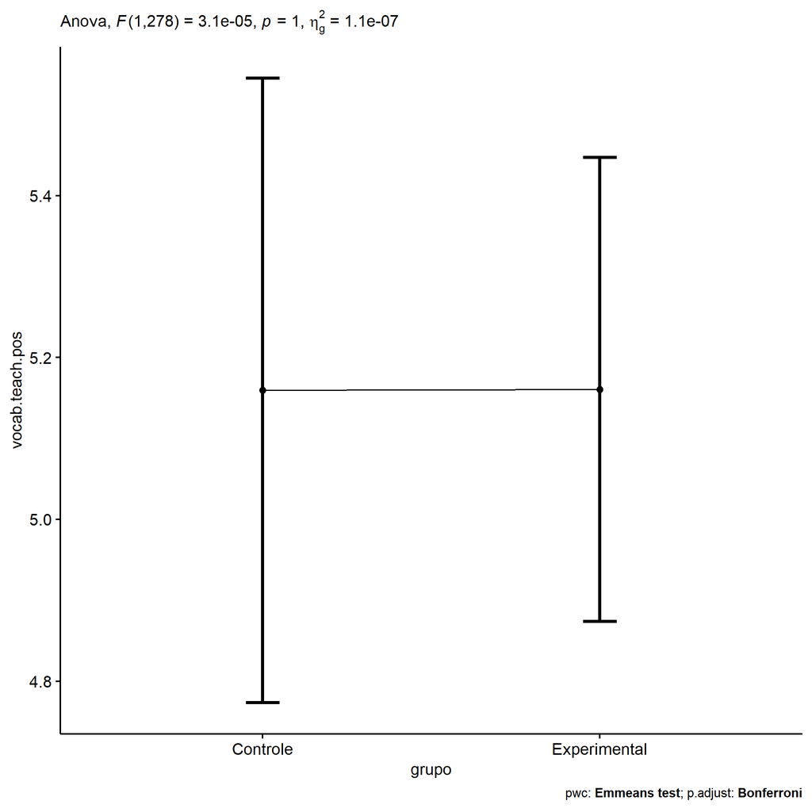

```r
if (!is.null(nrow(plots[["grupo"]]$data)))
  plots[["grupo"]] + ggplot2::scale_color_manual(values = color[["grupo"]])
```

```r
plots <- oneWayAncovaBoxPlots(
  wdat, "vocab.teach.pos", "grupo", aov, pwc, covar = "vocab.teach.pre",
  theme = "classic", color = color[["grupo"]],
  subtitle = which(aov$Effect == "grupo"))
```

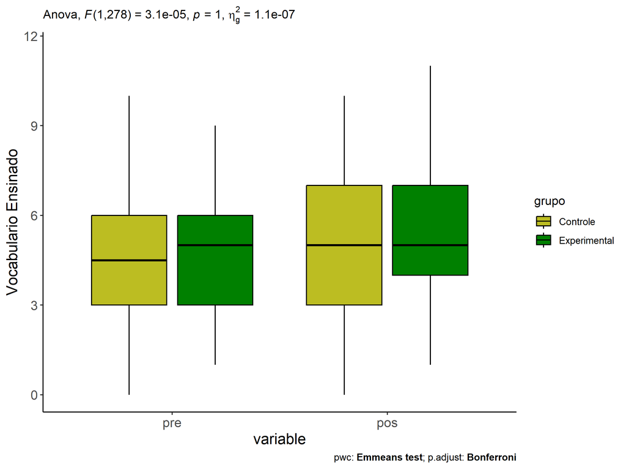

```r
if (length(unique(wdat[["grupo"]])) > 1)
  plots[["grupo"]] + ggplot2::ylab("Vocabulario Ensinado") + ggplot2::scale_x_discrete(labels=c('pre', 'pos'))
```

```r
if (length(unique(wdat.long[["grupo"]])) > 1)
  plots <- oneWayAncovaBoxPlots(
    wdat.long, "vocab.teach", "grupo", aov, pwc.long, pre.post = "time",
    theme = "classic", color = color$prepost)
```

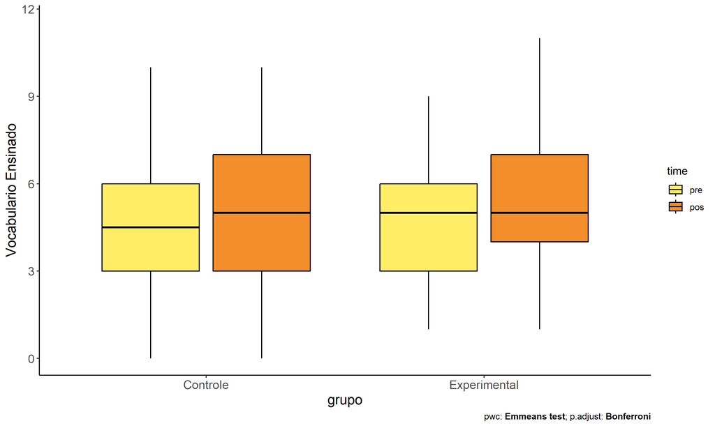

```r
if (length(unique(wdat.long[["grupo"]])) > 1)
  plots[["grupo"]] + ggplot2::ylab("Vocabulario Ensinado")
```

### Checking linearity assumption

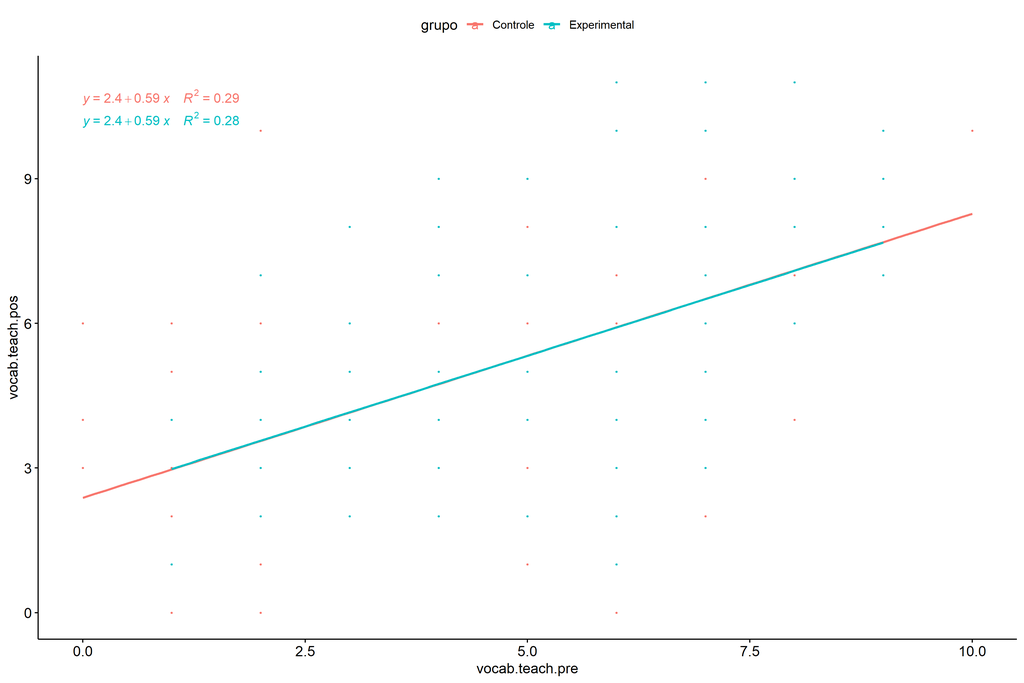

```r
ggscatter(wdat, x = "vocab.teach.pre", y = "vocab.teach.pos", size = 0.5,
          color = "grupo", add = "reg.line")+
  stat_regline_equation(
    aes(label =  paste(..eq.label.., ..rr.label.., sep = "~~~~"), color = grupo)
  )
```

### Checking normality and homogeneity

```r
res <- augment(lm(vocab.teach.pos ~ vocab.teach.pre + grupo, data = wdat))
```

```r
shapiro_test(res$.resid)
```

```
## # A tibble: 1 × 3
##   variable   statistic p.value
##   <chr>          <dbl>   <dbl>
## 1 res$.resid     0.996   0.691
```

```r
levene_test(res, .resid ~ grupo)
```

```
## # A tibble: 1 × 4
##     df1   df2 statistic     p
##   <int> <int>     <dbl> <dbl>
## 1     1   279      1.39 0.240
```

# ANCOVA and Pairwise for two factors **grupo:Sexo**

## Without remove non-normal data

```r
pdat = remove_group_data(dat[!is.na(dat[["grupo"]]) & !is.na(dat[["Sexo"]]),], "vocab.teach.pos", c("grupo","Sexo"))

pdat.long <- rbind(pdat[,c("id","grupo","Sexo")], pdat[,c("id","grupo","Sexo")])
pdat.long[["time"]] <- c(rep("pre", nrow(pdat)), rep("pos", nrow(pdat)))
pdat.long[["time"]] <- factor(pdat.long[["time"]], c("pre","pos"))
pdat.long[["vocab.teach"]] <- c(pdat[["vocab.teach.pre"]], pdat[["vocab.teach.pos"]])

aov = anova_test(pdat, vocab.teach.pos ~ vocab.teach.pre + grupo*Sexo)
laov[["grupo:Sexo"]] <- get_anova_table(aov)
```

```r
pwcs <- list()
pwcs[["Sexo"]] <- emmeans_test(
  group_by(pdat, grupo), vocab.teach.pos ~ Sexo,
  covariate = vocab.teach.pre, p.adjust.method = "bonferroni")
pwcs[["grupo"]] <- emmeans_test(
  group_by(pdat, Sexo), vocab.teach.pos ~ grupo,
  covariate = vocab.teach.pre, p.adjust.method = "bonferroni")

pwc <- plyr::rbind.fill(pwcs[["grupo"]], pwcs[["Sexo"]])
pwc <- pwc[,c("grupo","Sexo", colnames(pwc)[!colnames(pwc) %in% c("grupo","Sexo")])]
```

```r
pwc.long <- emmeans_test(dplyr::group_by_at(pdat.long, c("grupo","Sexo")),
                         vocab.teach ~ time,
                         p.adjust.method = "bonferroni")
lpwc[["grupo:Sexo"]] <- plyr::rbind.fill(pwc, pwc.long)
```

```r
ds <- get.descriptives(pdat, "vocab.teach.pos", c("grupo","Sexo"), covar = "vocab.teach.pre")
ds <- merge(ds[ds$variable != "vocab.teach.pre",],
            ds[ds$variable == "vocab.teach.pre", !colnames(ds) %in% c("variable")],
            by = c("grupo","Sexo"), all.x = T, suffixes = c("", ".vocab.teach.pre"))
ds <- merge(get_emmeans(pwcs[["grupo"]]), ds, by = c("grupo","Sexo"), suffixes = c(".emms", ""))
ds <- ds[,c("grupo","Sexo","n","mean.vocab.teach.pre","se.vocab.teach.pre","mean","se","emmean","se.emms")]

colnames(ds) <- c("grupo","Sexo", "N", paste0(c("M","SE")," (pre)"),
                  paste0(c("M","SE"), " (unadj)"), paste0(c("M", "SE"), " (adj)"))

lemms[["grupo:Sexo"]] <- ds
```

## Computing ANCOVA and PairWise After removing non-normal data (OK)

```r
wdat = pdat

res = residuals(lm(vocab.teach.pos ~ vocab.teach.pre + grupo*Sexo, data = wdat))
non.normal = getNonNormal(res, wdat$id, plimit = 0.05)

wdat = wdat[!wdat$id %in% non.normal,]

wdat.long <- rbind(wdat[,c("id","grupo","Sexo")], wdat[,c("id","grupo","Sexo")])
wdat.long[["time"]] <- c(rep("pre", nrow(wdat)), rep("pos", nrow(wdat)))
wdat.long[["time"]] <- factor(wdat.long[["time"]], c("pre","pos"))
wdat.long[["vocab.teach"]] <- c(wdat[["vocab.teach.pre"]], wdat[["vocab.teach.pos"]])


ldat[["grupo:Sexo"]] = wdat

(non.normal)
```

```r
aov = anova_test(wdat, vocab.teach.pos ~ vocab.teach.pre + grupo*Sexo)
laov[["grupo:Sexo"]] <- merge(get_anova_table(aov), laov[["grupo:Sexo"]], by="Effect", suffixes = c("","'"))

(df = get_anova_table(aov))
```

```
## ANOVA Table (type II tests)
##
##            Effect DFn DFd         F        p p<.05      ges
## 1 vocab.teach.pre   1 276 107.26200 1.89e-21     * 2.80e-01
## 2           grupo   1 276   0.00019 9.89e-01       6.88e-07
## 3            Sexo   1 276   4.75900 3.00e-02     * 1.70e-02
## 4      grupo:Sexo   1 276   3.73300 5.40e-02       1.30e-02
```

| Effect | DFn | DFd | F | p | p<.05 | ges |
| --- | --- | --- | --- | --- | --- | --- |
| vocab.teach.pre | 1 | 276 | 107.262 | 0.000 | * | 0.280 |
| grupo | 1 | 276 | 0.000 | 0.989 |  | 0.000 |
| Sexo | 1 | 276 | 4.759 | 0.030 | * | 0.017 |
| grupo:Sexo | 1 | 276 | 3.733 | 0.054 |  | 0.013 |

```r
pwcs <- list()
pwcs[["Sexo"]] <- emmeans_test(
  group_by(wdat, grupo), vocab.teach.pos ~ Sexo,
  covariate = vocab.teach.pre, p.adjust.method = "bonferroni")
pwcs[["grupo"]] <- emmeans_test(
  group_by(wdat, Sexo), vocab.teach.pos ~ grupo,
  covariate = vocab.teach.pre, p.adjust.method = "bonferroni")

pwc <- plyr::rbind.fill(pwcs[["grupo"]], pwcs[["Sexo"]])
pwc <- pwc[,c("grupo","Sexo", colnames(pwc)[!colnames(pwc) %in% c("grupo","Sexo")])]
```

| grupo | Sexo | term | .y. | group1 | group2 | df | statistic | p | p.adj | p.adj.signif |
| --- | --- | --- | --- | --- | --- | --- | --- | --- | --- | --- |
|  | F | vocab.teach.pre*grupo | vocab.teach.pos | Controle | Experimental | 276 | -1.334 | 0.183 | 0.183 | ns |
|  | M | vocab.teach.pre*grupo | vocab.teach.pos | Controle | Experimental | 276 | 1.396 | 0.164 | 0.164 | ns |
| Controle |  | vocab.teach.pre*Sexo | vocab.teach.pos | F | M | 276 | -0.244 | 0.807 | 0.807 | ns |
| Experimental |  | vocab.teach.pre*Sexo | vocab.teach.pos | F | M | 276 | 2.903 | 0.004 | 0.004 | ** |

```r
pwc.long <- emmeans_test(dplyr::group_by_at(wdat.long, c("grupo","Sexo")),
                         vocab.teach ~ time,
                         p.adjust.method = "bonferroni")
lpwc[["grupo:Sexo"]] <- merge(plyr::rbind.fill(pwc, pwc.long), lpwc[["grupo:Sexo"]], by=c("grupo","Sexo","term",".y.","group1","group2"), suffixes = c("","'"))
```

| grupo | Sexo | term | .y. | group1 | group2 | df | statistic | p | p.adj | p.adj.signif |
| --- | --- | --- | --- | --- | --- | --- | --- | --- | --- | --- |
| Controle | F | time | vocab.teach | pre | pos | 554 | -0.979 | 0.328 | 0.328 | ns |
| Controle | M | time | vocab.teach | pre | pos | 554 | -1.371 | 0.171 | 0.171 | ns |
| Experimental | F | time | vocab.teach | pre | pos | 554 | -2.348 | 0.019 | 0.019 | * |
| Experimental | M | time | vocab.teach | pre | pos | 554 | -0.141 | 0.888 | 0.888 | ns |

```r
ds <- get.descriptives(wdat, "vocab.teach.pos", c("grupo","Sexo"), covar = "vocab.teach.pre")
ds <- merge(ds[ds$variable != "vocab.teach.pre",],
            ds[ds$variable == "vocab.teach.pre", !colnames(ds) %in% c("variable")],
            by = c("grupo","Sexo"), all.x = T, suffixes = c("", ".vocab.teach.pre"))
ds <- merge(get_emmeans(pwcs[["grupo"]]), ds, by = c("grupo","Sexo"), suffixes = c(".emms", ""))
ds <- ds[,c("grupo","Sexo","n","mean.vocab.teach.pre","se.vocab.teach.pre","mean","se","emmean","se.emms")]

colnames(ds) <- c("grupo","Sexo", "N", paste0(c("M","SE")," (pre)"),
                  paste0(c("M","SE"), " (unadj)"), paste0(c("M", "SE"), " (adj)"))

lemms[["grupo:Sexo"]] <- merge(ds, lemms[["grupo:Sexo"]], by=c("grupo","Sexo"), suffixes = c("","'"))
```

| grupo | Sexo | N | M (pre) | SE (pre) | M (unadj) | SE (unadj) | M (adj) | SE (adj) |
| --- | --- | --- | --- | --- | --- | --- | --- | --- |
| Controle | F | 53 | 4.679 | 0.321 | 5.094 | 0.363 | 5.113 | 0.266 |
| Controle | M | 47 | 4.426 | 0.331 | 5.043 | 0.347 | 5.208 | 0.283 |
| Experimental | F | 96 | 4.958 | 0.207 | 5.698 | 0.225 | 5.555 | 0.198 |
| Experimental | M | 85 | 4.612 | 0.202 | 4.659 | 0.222 | 4.717 | 0.210 |

### Plots for ancova

```r
plots <- twoWayAncovaPlots(
  wdat, "vocab.teach.pos", c("grupo","Sexo"), aov, pwcs, addParam = c("mean_se"),
  font.label.size=10, step.increase=0.05, p.label="p.adj",
  subtitle = which(aov$Effect == "grupo:Sexo"))
```

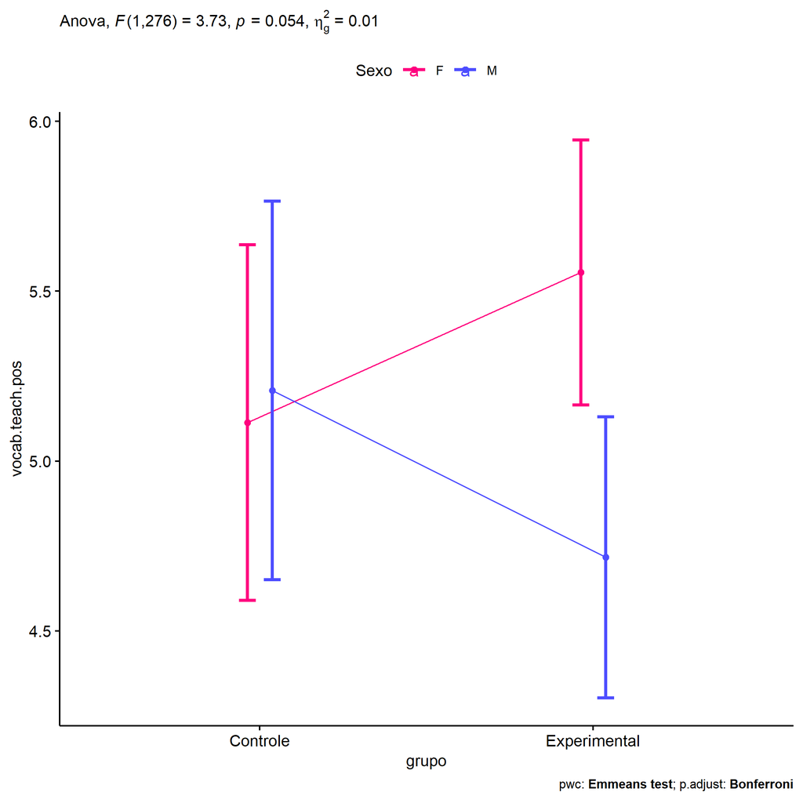

```r
if (!is.null(plots[["grupo"]]))
  plots[["grupo"]] + ggplot2::scale_color_manual(values = color[["Sexo"]])
```

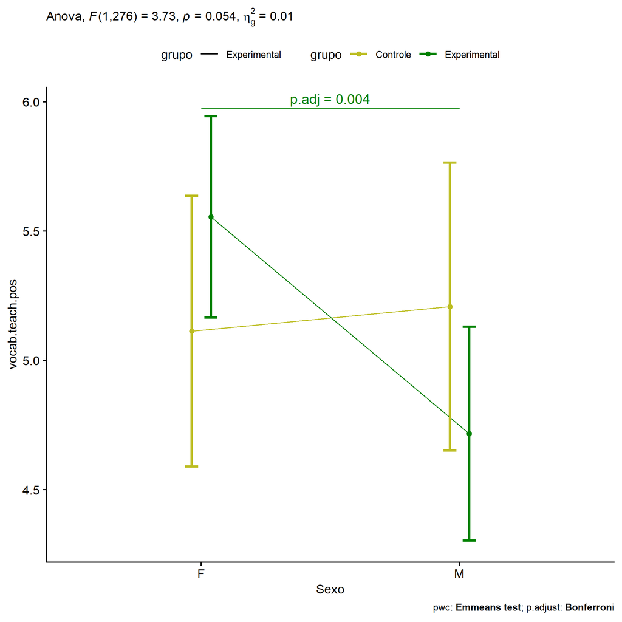

```r
if (!is.null(plots[["Sexo"]]))
  plots[["Sexo"]] + ggplot2::scale_color_manual(values = color[["grupo"]])
```

```r
plots <- twoWayAncovaBoxPlots(
  wdat, "vocab.teach.pos", c("grupo","Sexo"), aov, pwcs, covar = "vocab.teach.pre",
  theme = "classic", color = color[["grupo:Sexo"]],
  subtitle = which(aov$Effect == "grupo:Sexo"))
```

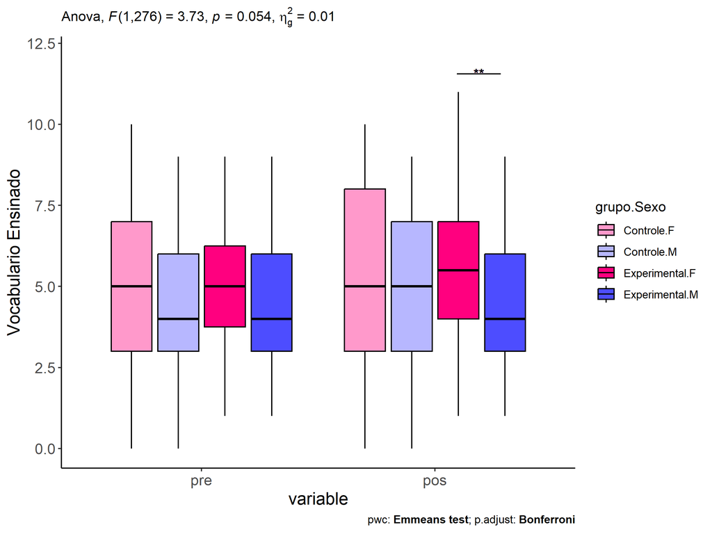

```r
plots[["grupo:Sexo"]] + ggplot2::ylab("Vocabulario Ensinado") + ggplot2::scale_x_discrete(labels=c('pre', 'pos'))
```

```r
plots <- twoWayAncovaBoxPlots(
  wdat.long, "vocab.teach", c("grupo","Sexo"), aov, pwc.long, pre.post = "time",
  theme = "classic", color = color$prepost)
```

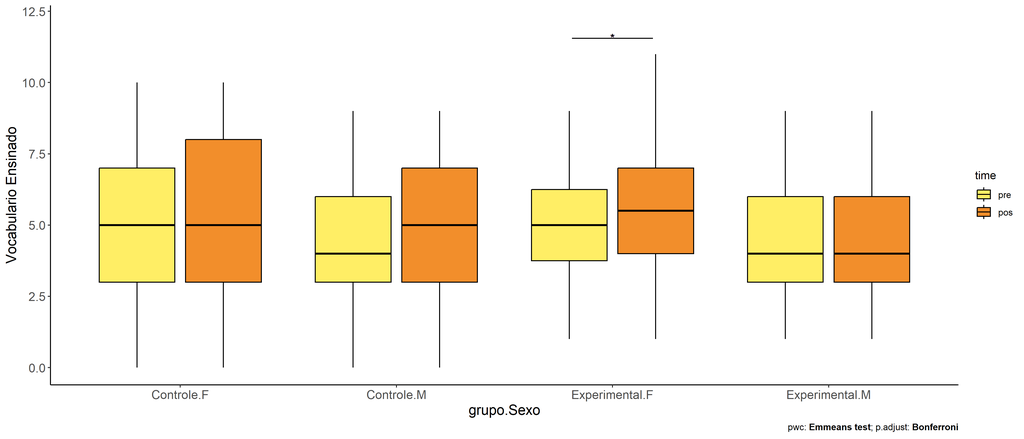

```r
plots[["grupo:Sexo"]] + ggplot2::ylab("Vocabulario Ensinado")
```

### Checking linearity assumption

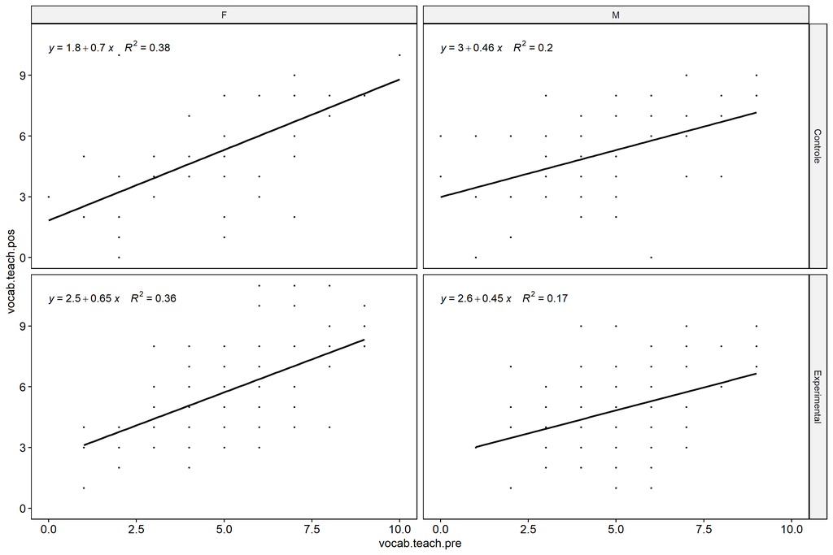

```r
ggscatter(wdat, x = "vocab.teach.pre", y = "vocab.teach.pos", size = 0.5,
          facet.by = c("grupo","Sexo"), add = "reg.line")+
  stat_regline_equation(
    aes(label =  paste(..eq.label.., ..rr.label.., sep = "~~~~"))
  )
```

### Checking normality and homogeneity

```r
res <- augment(lm(vocab.teach.pos ~ vocab.teach.pre + grupo*Sexo, data = wdat))
```

```r
shapiro_test(res$.resid)
```

```
## # A tibble: 1 × 3
##   variable   statistic p.value
##   <chr>          <dbl>   <dbl>
## 1 res$.resid     0.998   0.950
```

```r
levene_test(res, .resid ~ grupo*Sexo)
```

```
## # A tibble: 1 × 4
##     df1   df2 statistic     p
##   <int> <int>     <dbl> <dbl>
## 1     3   277     0.875 0.454
```

# ANCOVA and Pairwise for two factors **grupo:Zona**

## Without remove non-normal data

```r
pdat = remove_group_data(dat[!is.na(dat[["grupo"]]) & !is.na(dat[["Zona"]]),], "vocab.teach.pos", c("grupo","Zona"))

pdat.long <- rbind(pdat[,c("id","grupo","Zona")], pdat[,c("id","grupo","Zona")])
pdat.long[["time"]] <- c(rep("pre", nrow(pdat)), rep("pos", nrow(pdat)))
pdat.long[["time"]] <- factor(pdat.long[["time"]], c("pre","pos"))
pdat.long[["vocab.teach"]] <- c(pdat[["vocab.teach.pre"]], pdat[["vocab.teach.pos"]])

aov = anova_test(pdat, vocab.teach.pos ~ vocab.teach.pre + grupo*Zona)
laov[["grupo:Zona"]] <- get_anova_table(aov)
```

```r
pwcs <- list()
pwcs[["Zona"]] <- emmeans_test(
  group_by(pdat, grupo), vocab.teach.pos ~ Zona,
  covariate = vocab.teach.pre, p.adjust.method = "bonferroni")
pwcs[["grupo"]] <- emmeans_test(
  group_by(pdat, Zona), vocab.teach.pos ~ grupo,
  covariate = vocab.teach.pre, p.adjust.method = "bonferroni")

pwc <- plyr::rbind.fill(pwcs[["grupo"]], pwcs[["Zona"]])
pwc <- pwc[,c("grupo","Zona", colnames(pwc)[!colnames(pwc) %in% c("grupo","Zona")])]
```

```r
pwc.long <- emmeans_test(dplyr::group_by_at(pdat.long, c("grupo","Zona")),
                         vocab.teach ~ time,
                         p.adjust.method = "bonferroni")
lpwc[["grupo:Zona"]] <- plyr::rbind.fill(pwc, pwc.long)
```

```r
ds <- get.descriptives(pdat, "vocab.teach.pos", c("grupo","Zona"), covar = "vocab.teach.pre")
ds <- merge(ds[ds$variable != "vocab.teach.pre",],
            ds[ds$variable == "vocab.teach.pre", !colnames(ds) %in% c("variable")],
            by = c("grupo","Zona"), all.x = T, suffixes = c("", ".vocab.teach.pre"))
ds <- merge(get_emmeans(pwcs[["grupo"]]), ds, by = c("grupo","Zona"), suffixes = c(".emms", ""))
ds <- ds[,c("grupo","Zona","n","mean.vocab.teach.pre","se.vocab.teach.pre","mean","se","emmean","se.emms")]

colnames(ds) <- c("grupo","Zona", "N", paste0(c("M","SE")," (pre)"),
                  paste0(c("M","SE"), " (unadj)"), paste0(c("M", "SE"), " (adj)"))

lemms[["grupo:Zona"]] <- ds
```

## Computing ANCOVA and PairWise After removing non-normal data (OK)

```r
wdat = pdat

res = residuals(lm(vocab.teach.pos ~ vocab.teach.pre + grupo*Zona, data = wdat))
non.normal = getNonNormal(res, wdat$id, plimit = 0.05)

wdat = wdat[!wdat$id %in% non.normal,]

wdat.long <- rbind(wdat[,c("id","grupo","Zona")], wdat[,c("id","grupo","Zona")])
wdat.long[["time"]] <- c(rep("pre", nrow(wdat)), rep("pos", nrow(wdat)))
wdat.long[["time"]] <- factor(wdat.long[["time"]], c("pre","pos"))
wdat.long[["vocab.teach"]] <- c(wdat[["vocab.teach.pre"]], wdat[["vocab.teach.pos"]])


ldat[["grupo:Zona"]] = wdat

(non.normal)
```

```r
aov = anova_test(wdat, vocab.teach.pos ~ vocab.teach.pre + grupo*Zona)
laov[["grupo:Zona"]] <- merge(get_anova_table(aov), laov[["grupo:Zona"]], by="Effect", suffixes = c("","'"))

(df = get_anova_table(aov))
```

```
## ANOVA Table (type II tests)
##
##            Effect DFn DFd      F        p p<.05     ges
## 1 vocab.teach.pre   1 140 63.234 5.55e-13     * 0.31100
## 2           grupo   1 140  0.199 6.56e-01       0.00100
## 3            Zona   1 140  5.056 2.60e-02     * 0.03500
## 4      grupo:Zona   1 140  0.087 7.69e-01       0.00062
```

| Effect | DFn | DFd | F | p | p<.05 | ges |
| --- | --- | --- | --- | --- | --- | --- |
| vocab.teach.pre | 1 | 140 | 63.234 | 0.000 | * | 0.311 |
| grupo | 1 | 140 | 0.199 | 0.656 |  | 0.001 |
| Zona | 1 | 140 | 5.056 | 0.026 | * | 0.035 |
| grupo:Zona | 1 | 140 | 0.087 | 0.769 |  | 0.001 |

```r
pwcs <- list()
pwcs[["Zona"]] <- emmeans_test(
  group_by(wdat, grupo), vocab.teach.pos ~ Zona,
  covariate = vocab.teach.pre, p.adjust.method = "bonferroni")
pwcs[["grupo"]] <- emmeans_test(
  group_by(wdat, Zona), vocab.teach.pos ~ grupo,
  covariate = vocab.teach.pre, p.adjust.method = "bonferroni")

pwc <- plyr::rbind.fill(pwcs[["grupo"]], pwcs[["Zona"]])
pwc <- pwc[,c("grupo","Zona", colnames(pwc)[!colnames(pwc) %in% c("grupo","Zona")])]
```

| grupo | Zona | term | .y. | group1 | group2 | df | statistic | p | p.adj | p.adj.signif |
| --- | --- | --- | --- | --- | --- | --- | --- | --- | --- | --- |
|  | Rural | vocab.teach.pre*grupo | vocab.teach.pos | Controle | Experimental | 140 | -0.534 | 0.594 | 0.594 | ns |
|  | Urbana | vocab.teach.pre*grupo | vocab.teach.pos | Controle | Experimental | 140 | -0.021 | 0.984 | 0.984 | ns |
| Controle |  | vocab.teach.pre*Zona | vocab.teach.pos | Rural | Urbana | 140 | -1.602 | 0.111 | 0.111 | ns |
| Experimental |  | vocab.teach.pre*Zona | vocab.teach.pos | Rural | Urbana | 140 | -1.608 | 0.110 | 0.110 | ns |

```r
pwc.long <- emmeans_test(dplyr::group_by_at(wdat.long, c("grupo","Zona")),
                         vocab.teach ~ time,
                         p.adjust.method = "bonferroni")
lpwc[["grupo:Zona"]] <- merge(plyr::rbind.fill(pwc, pwc.long), lpwc[["grupo:Zona"]], by=c("grupo","Zona","term",".y.","group1","group2"), suffixes = c("","'"))
```

| grupo | Zona | term | .y. | group1 | group2 | df | statistic | p | p.adj | p.adj.signif |
| --- | --- | --- | --- | --- | --- | --- | --- | --- | --- | --- |
| Controle | Rural | time | vocab.teach | pre | pos | 282 | -0.373 | 0.710 | 0.710 | ns |
| Controle | Urbana | time | vocab.teach | pre | pos | 282 | -1.701 | 0.090 | 0.090 | ns |
| Experimental | Rural | time | vocab.teach | pre | pos | 282 | -0.877 | 0.381 | 0.381 | ns |
| Experimental | Urbana | time | vocab.teach | pre | pos | 282 | -2.056 | 0.041 | 0.041 | * |

```r
ds <- get.descriptives(wdat, "vocab.teach.pos", c("grupo","Zona"), covar = "vocab.teach.pre")
ds <- merge(ds[ds$variable != "vocab.teach.pre",],
            ds[ds$variable == "vocab.teach.pre", !colnames(ds) %in% c("variable")],
            by = c("grupo","Zona"), all.x = T, suffixes = c("", ".vocab.teach.pre"))
ds <- merge(get_emmeans(pwcs[["grupo"]]), ds, by = c("grupo","Zona"), suffixes = c(".emms", ""))
ds <- ds[,c("grupo","Zona","n","mean.vocab.teach.pre","se.vocab.teach.pre","mean","se","emmean","se.emms")]

colnames(ds) <- c("grupo","Zona", "N", paste0(c("M","SE")," (pre)"),
                  paste0(c("M","SE"), " (unadj)"), paste0(c("M", "SE"), " (adj)"))

lemms[["grupo:Zona"]] <- merge(ds, lemms[["grupo:Zona"]], by=c("grupo","Zona"), suffixes = c("","'"))
```

| grupo | Zona | N | M (pre) | SE (pre) | M (unadj) | SE (unadj) | M (adj) | SE (adj) |
| --- | --- | --- | --- | --- | --- | --- | --- | --- |
| Controle | Rural | 38 | 4.658 | 0.318 | 4.842 | 0.414 | 4.836 | 0.313 |
| Controle | Urbana | 18 | 4.222 | 0.592 | 5.444 | 0.561 | 5.723 | 0.457 |
| Experimental | Rural | 56 | 4.786 | 0.268 | 5.143 | 0.300 | 5.053 | 0.258 |
| Experimental | Urbana | 33 | 4.636 | 0.275 | 5.727 | 0.370 | 5.735 | 0.336 |

### Plots for ancova

```r
plots <- twoWayAncovaPlots(
  wdat, "vocab.teach.pos", c("grupo","Zona"), aov, pwcs, addParam = c("mean_se"),
  font.label.size=10, step.increase=0.05, p.label="p.adj",
  subtitle = which(aov$Effect == "grupo:Zona"))
```

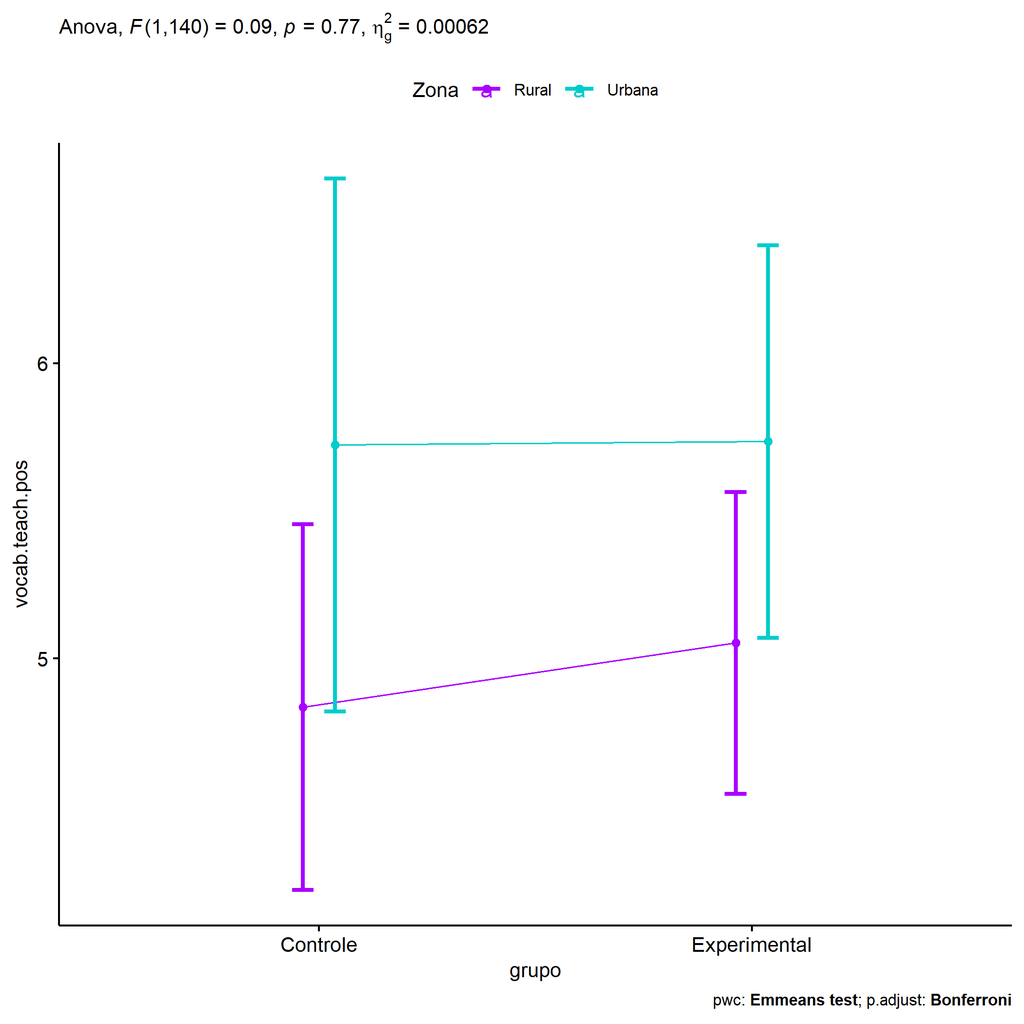

```r
if (!is.null(plots[["grupo"]]))
  plots[["grupo"]] + ggplot2::scale_color_manual(values = color[["Zona"]])
```

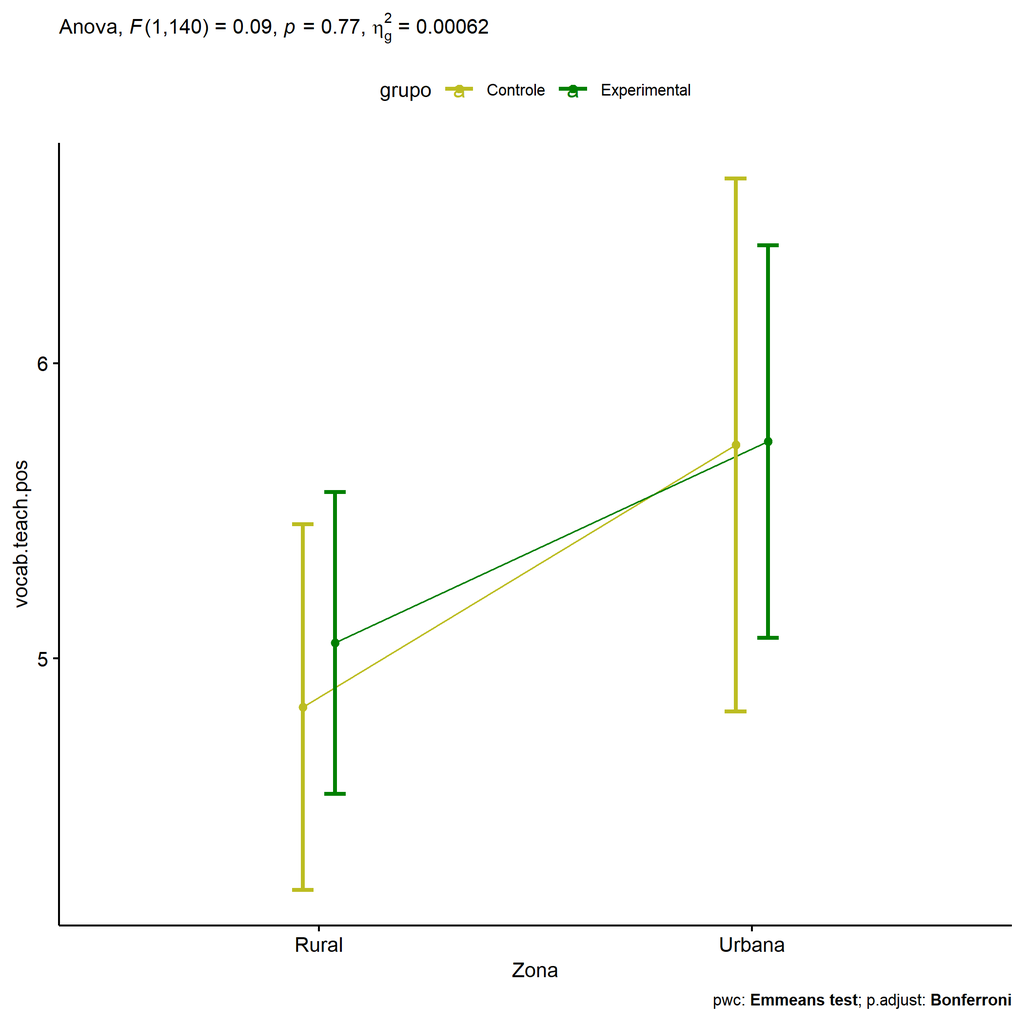

```r
if (!is.null(plots[["Zona"]]))
  plots[["Zona"]] + ggplot2::scale_color_manual(values = color[["grupo"]])
```

```r
plots <- twoWayAncovaBoxPlots(
  wdat, "vocab.teach.pos", c("grupo","Zona"), aov, pwcs, covar = "vocab.teach.pre",
  theme = "classic", color = color[["grupo:Zona"]],
  subtitle = which(aov$Effect == "grupo:Zona"))
```

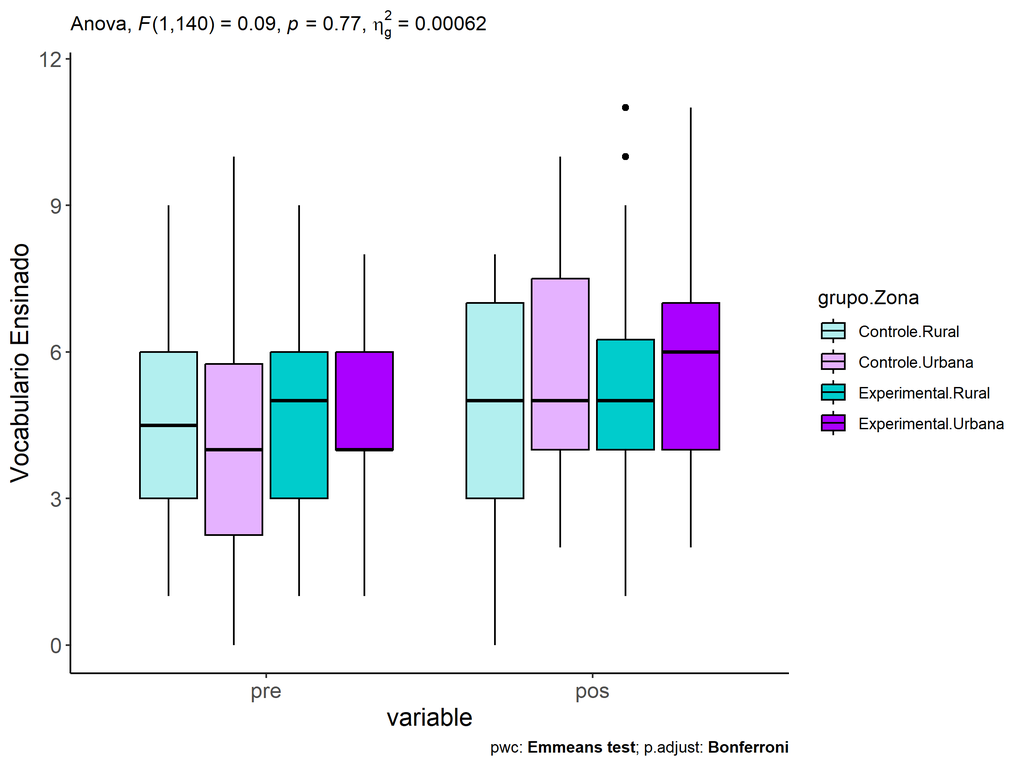

```r
plots[["grupo:Zona"]] + ggplot2::ylab("Vocabulario Ensinado") + ggplot2::scale_x_discrete(labels=c('pre', 'pos'))
```

```r
plots <- twoWayAncovaBoxPlots(
  wdat.long, "vocab.teach", c("grupo","Zona"), aov, pwc.long, pre.post = "time",
  theme = "classic", color = color$prepost)
```

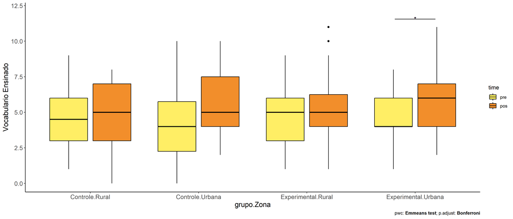

```r
plots[["grupo:Zona"]] + ggplot2::ylab("Vocabulario Ensinado")
```

### Checking linearity assumption

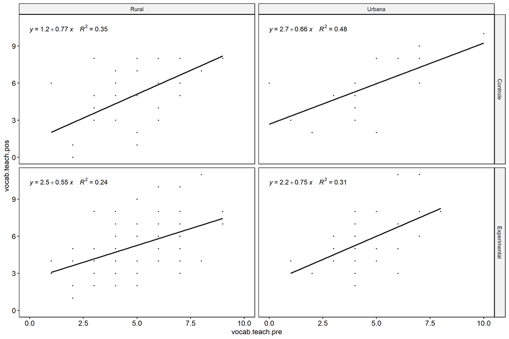

```r
ggscatter(wdat, x = "vocab.teach.pre", y = "vocab.teach.pos", size = 0.5,
          facet.by = c("grupo","Zona"), add = "reg.line")+
  stat_regline_equation(
    aes(label =  paste(..eq.label.., ..rr.label.., sep = "~~~~"))
  )
```

### Checking normality and homogeneity

```r
res <- augment(lm(vocab.teach.pos ~ vocab.teach.pre + grupo*Zona, data = wdat))
```

```r
shapiro_test(res$.resid)
```

```
## # A tibble: 1 × 3
##   variable   statistic p.value
##   <chr>          <dbl>   <dbl>
## 1 res$.resid     0.985   0.132
```

```r
levene_test(res, .resid ~ grupo*Zona)
```

```
## # A tibble: 1 × 4
##     df1   df2 statistic     p
##   <int> <int>     <dbl> <dbl>
## 1     3   141      1.04 0.377
```

# ANCOVA and Pairwise for two factors **grupo:Cor.Raca**

## Without remove non-normal data

```r
pdat = remove_group_data(dat[!is.na(dat[["grupo"]]) & !is.na(dat[["Cor.Raca"]]),], "vocab.teach.pos", c("grupo","Cor.Raca"))
pdat.long <- rbind(pdat[,c("id","grupo","Cor.Raca")], pdat[,c("id","grupo","Cor.Raca")])
pdat.long[["time"]] <- c(rep("pre", nrow(pdat)), rep("pos", nrow(pdat)))
pdat.long[["time"]] <- factor(pdat.long[["time"]], c("pre","pos"))
pdat.long[["vocab.teach"]] <- c(pdat[["vocab.teach.pre"]], pdat[["vocab.teach.pos"]])

aov = anova_test(pdat, vocab.teach.pos ~ vocab.teach.pre + grupo*Cor.Raca)
laov[["grupo:Cor.Raca"]] <- get_anova_table(aov)
```

```r
pwcs <- list()
pwcs[["Cor.Raca"]] <- emmeans_test(
  group_by(pdat, grupo), vocab.teach.pos ~ Cor.Raca,
  covariate = vocab.teach.pre, p.adjust.method = "bonferroni")
pwcs[["grupo"]] <- emmeans_test(
  group_by(pdat, Cor.Raca), vocab.teach.pos ~ grupo,
  covariate = vocab.teach.pre, p.adjust.method = "bonferroni")

pwc <- plyr::rbind.fill(pwcs[["grupo"]], pwcs[["Cor.Raca"]])
pwc <- pwc[,c("grupo","Cor.Raca", colnames(pwc)[!colnames(pwc) %in% c("grupo","Cor.Raca")])]
```

```r
pwc.long <- emmeans_test(dplyr::group_by_at(pdat.long, c("grupo","Cor.Raca")),
                         vocab.teach ~ time,
                         p.adjust.method = "bonferroni")
lpwc[["grupo:Cor.Raca"]] <- plyr::rbind.fill(pwc, pwc.long)
```

```r
ds <- get.descriptives(pdat, "vocab.teach.pos", c("grupo","Cor.Raca"), covar = "vocab.teach.pre")
ds <- merge(ds[ds$variable != "vocab.teach.pre",],
            ds[ds$variable == "vocab.teach.pre", !colnames(ds) %in% c("variable")],
            by = c("grupo","Cor.Raca"), all.x = T, suffixes = c("", ".vocab.teach.pre"))
ds <- merge(get_emmeans(pwcs[["grupo"]]), ds, by = c("grupo","Cor.Raca"), suffixes = c(".emms", ""))
ds <- ds[,c("grupo","Cor.Raca","n","mean.vocab.teach.pre","se.vocab.teach.pre","mean","se","emmean","se.emms")]

colnames(ds) <- c("grupo","Cor.Raca", "N", paste0(c("M","SE")," (pre)"),
                  paste0(c("M","SE"), " (unadj)"), paste0(c("M", "SE"), " (adj)"))

lemms[["grupo:Cor.Raca"]] <- ds
```

## Computing ANCOVA and PairWise After removing non-normal data (OK)

```r
wdat = pdat

res = residuals(lm(vocab.teach.pos ~ vocab.teach.pre + grupo*Cor.Raca, data = wdat))
non.normal = getNonNormal(res, wdat$id, plimit = 0.05)

wdat = wdat[!wdat$id %in% non.normal,]

wdat.long <- rbind(wdat[,c("id","grupo","Cor.Raca")], wdat[,c("id","grupo","Cor.Raca")])
wdat.long[["time"]] <- c(rep("pre", nrow(wdat)), rep("pos", nrow(wdat)))
wdat.long[["time"]] <- factor(wdat.long[["time"]], c("pre","pos"))
wdat.long[["vocab.teach"]] <- c(wdat[["vocab.teach.pre"]], wdat[["vocab.teach.pos"]])


ldat[["grupo:Cor.Raca"]] = wdat

(non.normal)
```

```r
aov = anova_test(wdat, vocab.teach.pos ~ vocab.teach.pre + grupo*Cor.Raca)
laov[["grupo:Cor.Raca"]] <- merge(get_anova_table(aov), laov[["grupo:Cor.Raca"]], by="Effect", suffixes = c("","'"))

(df = get_anova_table(aov))
```

```
## ANOVA Table (type II tests)
##
##            Effect DFn DFd      F        p p<.05   ges
## 1 vocab.teach.pre   1 106 48.953 2.46e-10     * 0.316
## 2           grupo   1 106  0.857 3.57e-01       0.008
## 3        Cor.Raca   1 106  0.410 5.23e-01       0.004
## 4  grupo:Cor.Raca   0 106     NA       NA  <NA>    NA
```

| Effect | DFn | DFd | F | p | p<.05 | ges |
| --- | --- | --- | --- | --- | --- | --- |
| vocab.teach.pre | 1 | 106 | 48.953 | 0.000 | * | 0.316 |
| grupo | 1 | 106 | 0.857 | 0.357 |  | 0.008 |
| Cor.Raca | 1 | 106 | 0.410 | 0.523 |  | 0.004 |
| grupo:Cor.Raca | 0 | 106 |  |  |  |  |

```r
pwcs <- list()
pwcs[["Cor.Raca"]] <- emmeans_test(
  group_by(wdat, grupo), vocab.teach.pos ~ Cor.Raca,
  covariate = vocab.teach.pre, p.adjust.method = "bonferroni")
pwcs[["grupo"]] <- emmeans_test(
  group_by(wdat, Cor.Raca), vocab.teach.pos ~ grupo,
  covariate = vocab.teach.pre, p.adjust.method = "bonferroni")

pwc <- plyr::rbind.fill(pwcs[["grupo"]], pwcs[["Cor.Raca"]])
pwc <- pwc[,c("grupo","Cor.Raca", colnames(pwc)[!colnames(pwc) %in% c("grupo","Cor.Raca")])]
```

| grupo | Cor.Raca | term | .y. | group1 | group2 | df | statistic | p | p.adj | p.adj.signif |
| --- | --- | --- | --- | --- | --- | --- | --- | --- | --- | --- |
|  | Branca | vocab.teach.pre*grupo | vocab.teach.pos | Controle | Experimental |  |  |  |  |  |
|  | Parda | vocab.teach.pre*grupo | vocab.teach.pos | Controle | Experimental | 106 | -0.926 | 0.357 | 0.357 | ns |
| Controle |  | vocab.teach.pre*Cor.Raca | vocab.teach.pos | Branca | Parda |  |  |  |  |  |
| Experimental |  | vocab.teach.pre*Cor.Raca | vocab.teach.pos | Branca | Parda | 106 | -0.640 | 0.523 | 0.523 | ns |

```r
pwc.long <- emmeans_test(dplyr::group_by_at(wdat.long, c("grupo","Cor.Raca")),
                         vocab.teach ~ time,
                         p.adjust.method = "bonferroni")
lpwc[["grupo:Cor.Raca"]] <- merge(plyr::rbind.fill(pwc, pwc.long), lpwc[["grupo:Cor.Raca"]], by=c("grupo","Cor.Raca","term",".y.","group1","group2"), suffixes = c("","'"))
```

| grupo | Cor.Raca | term | .y. | group1 | group2 | df | statistic | p | p.adj | p.adj.signif |
| --- | --- | --- | --- | --- | --- | --- | --- | --- | --- | --- |
| Controle | Branca | time | vocab.teach | pre | pos |  |  |  |  |  |
| Controle | Parda | time | vocab.teach | pre | pos | 214 | -0.368 | 0.713 | 0.713 | ns |
| Experimental | Branca | time | vocab.teach | pre | pos | 214 | -0.223 | 0.824 | 0.824 | ns |
| Experimental | Parda | time | vocab.teach | pre | pos | 214 | -1.470 | 0.143 | 0.143 | ns |

```r
ds <- get.descriptives(wdat, "vocab.teach.pos", c("grupo","Cor.Raca"), covar = "vocab.teach.pre")
ds <- merge(ds[ds$variable != "vocab.teach.pre",],
            ds[ds$variable == "vocab.teach.pre", !colnames(ds) %in% c("variable")],
            by = c("grupo","Cor.Raca"), all.x = T, suffixes = c("", ".vocab.teach.pre"))
ds <- merge(get_emmeans(pwcs[["grupo"]]), ds, by = c("grupo","Cor.Raca"), suffixes = c(".emms", ""))
ds <- ds[,c("grupo","Cor.Raca","n","mean.vocab.teach.pre","se.vocab.teach.pre","mean","se","emmean","se.emms")]

colnames(ds) <- c("grupo","Cor.Raca", "N", paste0(c("M","SE")," (pre)"),
                  paste0(c("M","SE"), " (unadj)"), paste0(c("M", "SE"), " (adj)"))

lemms[["grupo:Cor.Raca"]] <- merge(ds, lemms[["grupo:Cor.Raca"]], by=c("grupo","Cor.Raca"), suffixes = c("","'"))
```

| grupo | Cor.Raca | N | M (pre) | SE (pre) | M (unadj) | SE (unadj) | M (adj) | SE (adj) |
| --- | --- | --- | --- | --- | --- | --- | --- | --- |
| Controle | Parda | 38 | 4.789 | 0.297 | 4.974 | 0.419 | 4.955 | 0.326 |
| Experimental | Branca | 19 | 5.053 | 0.401 | 5.211 | 0.499 | 5.006 | 0.461 |
| Experimental | Parda | 53 | 4.642 | 0.279 | 5.264 | 0.326 | 5.351 | 0.276 |